# Tarea 3

Jose Aguilar, Eilyn Salazar, Crisia Piedra

May 6, 2020

# Entendimiento del negocio

El problema a evaluar consiste en identificar patrones o caracteristicas en común de los miembros del cantón #21 de San José y basado en estás caracteristicas crear grupos de trabajo para sacar adelante los proyectos de interés del cantón.

## Objetivos de minería de datos

- Identificar las 3 mejores reglas que describen que atributos suelen reunir determinados miembros de la comunidad.

## Criterios de éxito desde la perspectiva de minería de datos

- Evaluar la confianza del modelo a priori con el fin de validar que la confianza de las reglas seleccionadas sea mayor al 90%.

# Entendimiento de los datos

## Exploración de los datos

El conjunto de datos encuesta.csv contiene los siguientes campos:

```r
setwd('C:/Curso TEC/Tarea3/CienciasDeDatos/05_Mineria_De_Datos/Tarea3')
atributos<-read.csv('descripcion_atributos.csv', sep = ',',dec = '.')
kable(atributos[,0:3])
```

[output not shown]

## Verificación de la calidad de datos

Para la evaluación de la calidad de los datos, se emplea la función summary para identificar la presencia de valores nulos, así como valores minimos y máximos de las variables númericas a fin de validar, si a simple vista es posible encontrar outliers o valores fuera de rango, como valores negativos.

```r
dataset<-read.csv('Encuesta.csv', sep = ',',dec = '.')
str(dataset)
```

```
## 'data.frame':    3483 obs. of  12 variables:
##  $ Tiempo_Respuesta: num  8.71 5.24 4.22 4.81 3.95 9.35 2.91 4.54 4.79 3.07 ...
##  $ Tiempo_comunidad: Factor w/ 3 levels "Corto","Largo",..: 1 3 3 2 2 2 3 3 1 3 ...
##  $ Sexo            : Factor w/ 2 levels "F","M": 2 1 2 1 2 1 1 2 1 2 ...
##  $ Trabaja         : Factor w/ 2 levels "No","Si": 1 1 1 1 2 1 2 2 1 1 ...
##  $ Edad            : int  53 31 42 30 29 40 33 27 50 28 ...
##  $ Familia         : int  1 0 1 0 0 0 0 1 1 0 ...
##  $ Hobbies         : int  0 0 1 0 0 0 0 1 1 0 ...
##  $ Club_Social     : int  0 0 0 0 0 0 0 1 0 0 ...
##  $ Politica        : int  0 0 0 0 1 0 0 0 0 0 ...
##  $ Profesional     : int  0 0 1 0 1 1 0 0 1 0 ...
##  $ Medioambiente   : int  0 1 0 0 0 0 0 1 1 1 ...
##  $ Grupo_Apoyo     : int  0 1 0 0 1 0 1 0 0 1 ...
```

```r
summary(dataset)
```

```
##  Tiempo_Respuesta Tiempo_comunidad Sexo     Trabaja        Edad
##  Min.   : 2.010   Corto: 714       F:1790   No:1739   Min.   :17.00
##  1st Qu.: 3.875   Largo:1465       M:1693   Si:1744   1st Qu.:27.00
##  Median : 5.930   Medio:1304                          Median :36.00
##  Mean   : 5.922                                       Mean   :36.73
##  3rd Qu.: 7.840                                       3rd Qu.:46.00
##  Max.   :10.150                                       Max.   :57.00
##     Familia          Hobbies     Club_Social        Politica
##  Min.   :0.0000   Min.   :0.0   Min.   :0.0000   Min.   :0.00000
##  1st Qu.:0.0000   1st Qu.:0.0   1st Qu.:0.0000   1st Qu.:0.00000
##  Median :0.0000   Median :0.0   Median :0.0000   Median :0.00000
##  Mean   :0.3899   Mean   :0.3   Mean   :0.1881   Mean   :0.09388
##  3rd Qu.:1.0000   3rd Qu.:1.0   3rd Qu.:0.0000   3rd Qu.:0.00000
##  Max.   :1.0000   Max.   :1.0   Max.   :1.0000   Max.   :1.00000
##   Profesional     Medioambiente     Grupo_Apoyo
##  Min.   :0.0000   Min.   :0.0000   Min.   :0.0000
##  1st Qu.:0.0000   1st Qu.:0.0000   1st Qu.:0.0000
##  Median :0.0000   Median :0.0000   Median :0.0000
##  Mean   :0.3244   Mean   :0.4186   Mean   :0.1588
##  3rd Qu.:1.0000   3rd Qu.:1.0000   3rd Qu.:0.0000
##  Max.   :1.0000   Max.   :1.0000   Max.   :1.0000
```

Como se puede observar en la tabla anterior, no se encontraron valores nulos ni negativos.

# Preparación de los datos

La primera tranformación de los datos consiste en convertir las columnas Trabaja y Familia a un valor numérico para que sea consistente con las demás variables:

```r
# Lo convertimos usando as.integer(), pero debemos restarle 1 para que quede con dos valores 0 y 1, en vez de 1 y 2 como funciona al convertir de factor a entero
dataset$Trabaja1 <- as.integer(dataset$Trabaja)-1
dataset$Familia <- as.integer(dataset$Familia)-1
dataset$Familia<- factor(dataset$Familia,labels=c("No","Si"))
dataset$Trabaja<- factor(dataset$Trabaja,labels=c("No","Si"))
dataset$Hobbies<- factor(dataset$Hobbies,labels=c("No","Si"))
dataset$Club_Social<- factor(dataset$Club_Social,labels=c("No","Si"))
dataset$Politica<- factor(dataset$Politica,labels=c("No","Si"))
dataset$Profesional<- factor(dataset$Profesional,labels=c("No","Si"))
dataset$Medioambiente<- factor(dataset$Medioambiente,labels=c("No","Si"))
dataset$Grupo_Apoyo<- factor(dataset$Grupo_Apoyo,labels=c("No","Si"))
str(dataset)
```

```
## 'data.frame':    3483 obs. of  13 variables:
##  $ Tiempo_Respuesta: num  8.71 5.24 4.22 4.81 3.95 9.35 2.91 4.54 4.79 3.07 ...
##  $ Tiempo_comunidad: Factor w/ 3 levels "Corto","Largo",..: 1 3 3 2 2 2 3 3 1 3 ...
##  $ Sexo            : Factor w/ 2 levels "F","M": 2 1 2 1 2 1 1 2 1 2 ...
##  $ Trabaja         : Factor w/ 2 levels "No","Si": 1 1 1 1 2 1 2 2 1 1 ...
##  $ Edad            : int  53 31 42 30 29 40 33 27 50 28 ...
##  $ Familia         : Factor w/ 2 levels "No","Si": 2 1 2 1 1 1 1 2 2 1 ...
##  $ Hobbies         : Factor w/ 2 levels "No","Si": 1 1 2 1 1 1 1 2 2 1 ...
##  $ Club_Social     : Factor w/ 2 levels "No","Si": 1 1 1 1 1 1 1 2 1 1 ...
##  $ Politica        : Factor w/ 2 levels "No","Si": 1 1 1 1 2 1 1 1 1 1 ...
##  $ Profesional     : Factor w/ 2 levels "No","Si": 1 1 2 1 2 2 1 1 2 1 ...
##  $ Medioambiente   : Factor w/ 2 levels "No","Si": 1 2 1 1 1 1 1 2 2 2 ...
##  $ Grupo_Apoyo     : Factor w/ 2 levels "No","Si": 1 2 1 1 2 1 2 1 1 2 ...
##  $ Trabaja1        : num  0 0 0 0 1 0 1 1 0 0 ...
```

## Graficos de distribución de los valores de las variables que son factores:

A fin de explorar la distribución de las variables se crean los siguientes gráficos.

```
## [1] "Tiempo_comunidad"
```

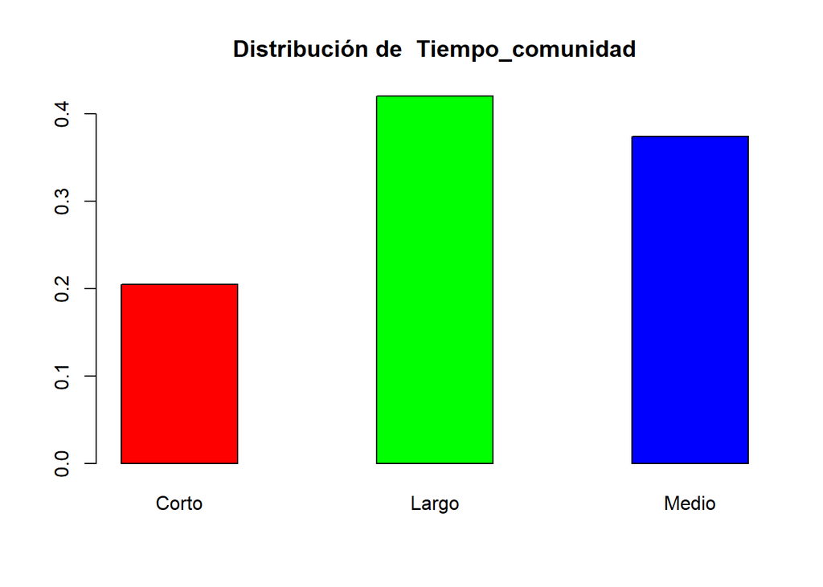

```
## [1] "Sexo"
```

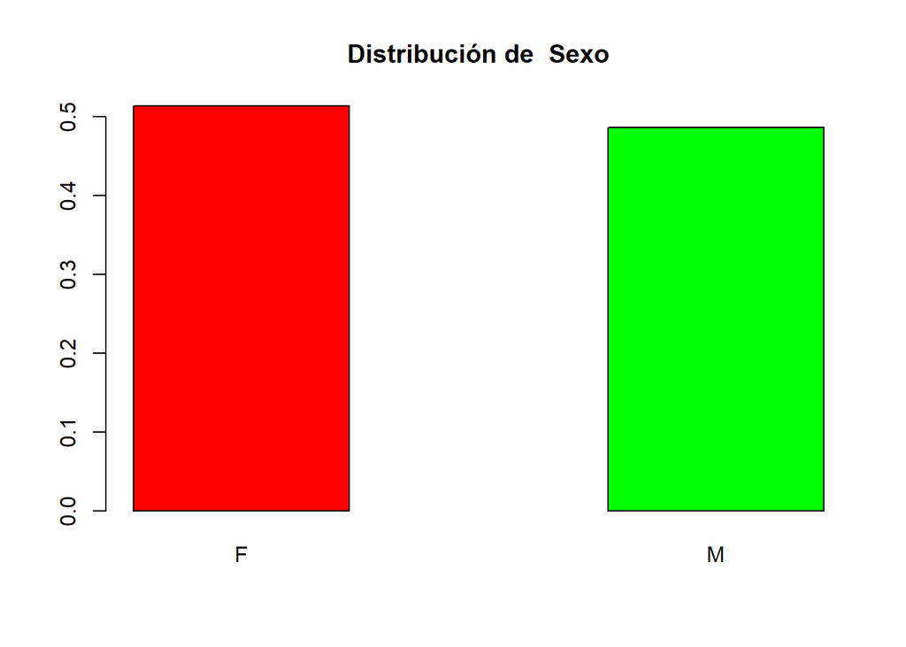

```
## [1] "Trabaja"
```

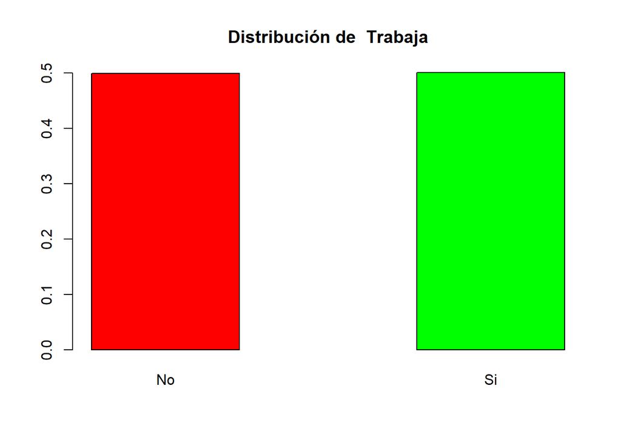

```
## [1] "Familia"
```

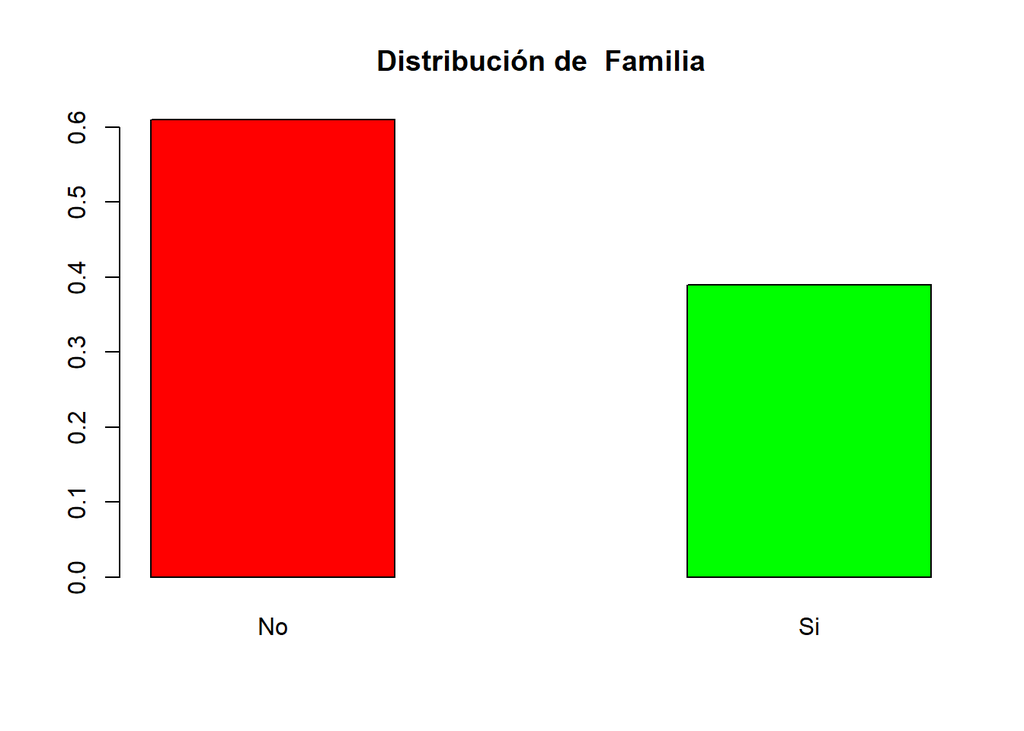

```
## [1] "Hobbies"
```

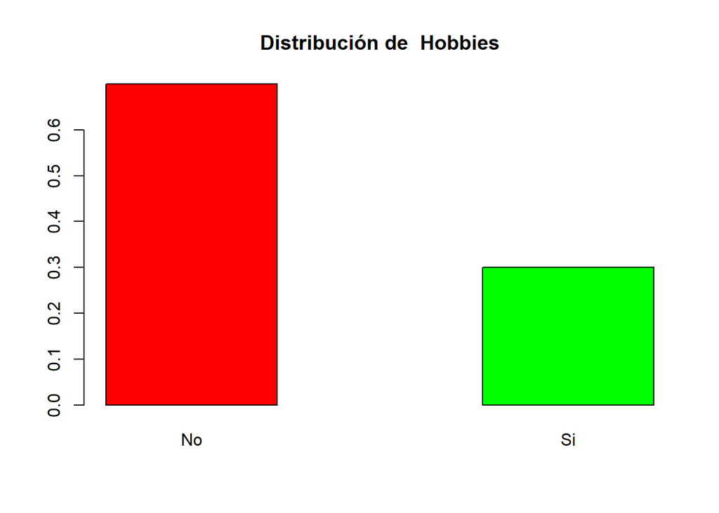

```
## [1] "Club_Social"
```

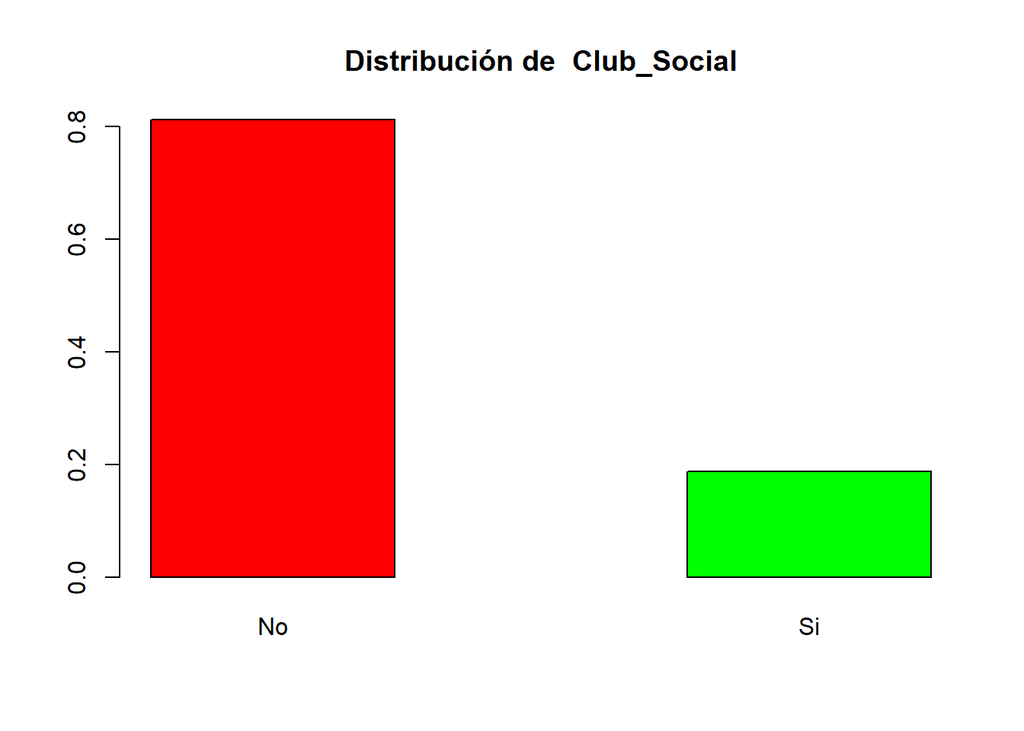

```
## [1] "Politica"
```

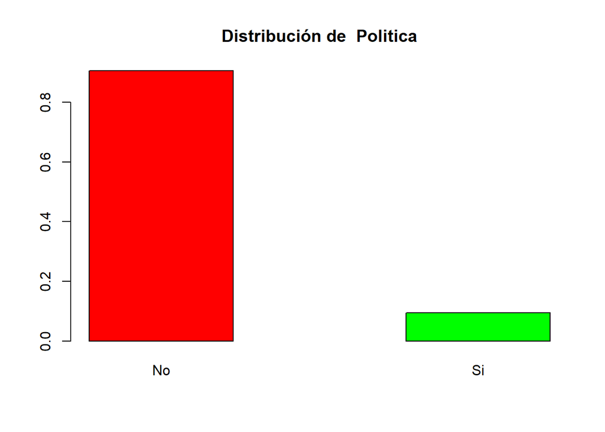

```
## [1] "Profesional"
```

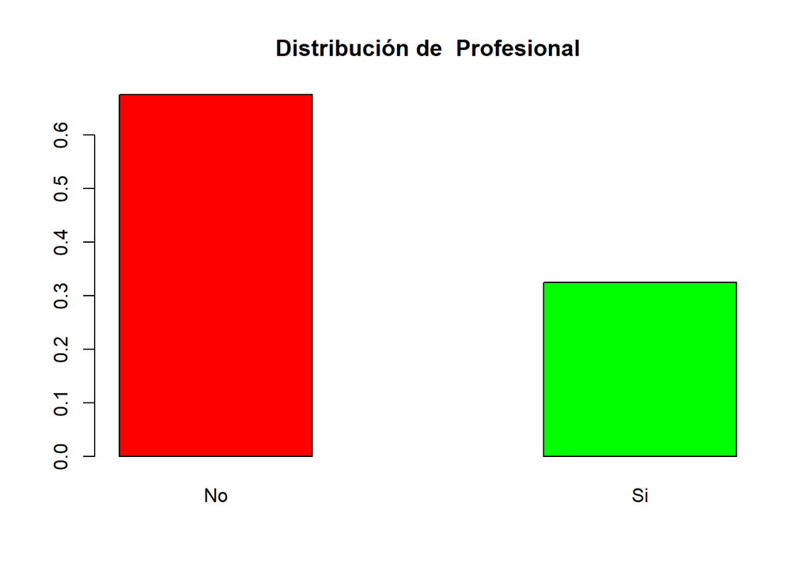

```
## [1] "Medioambiente"
```

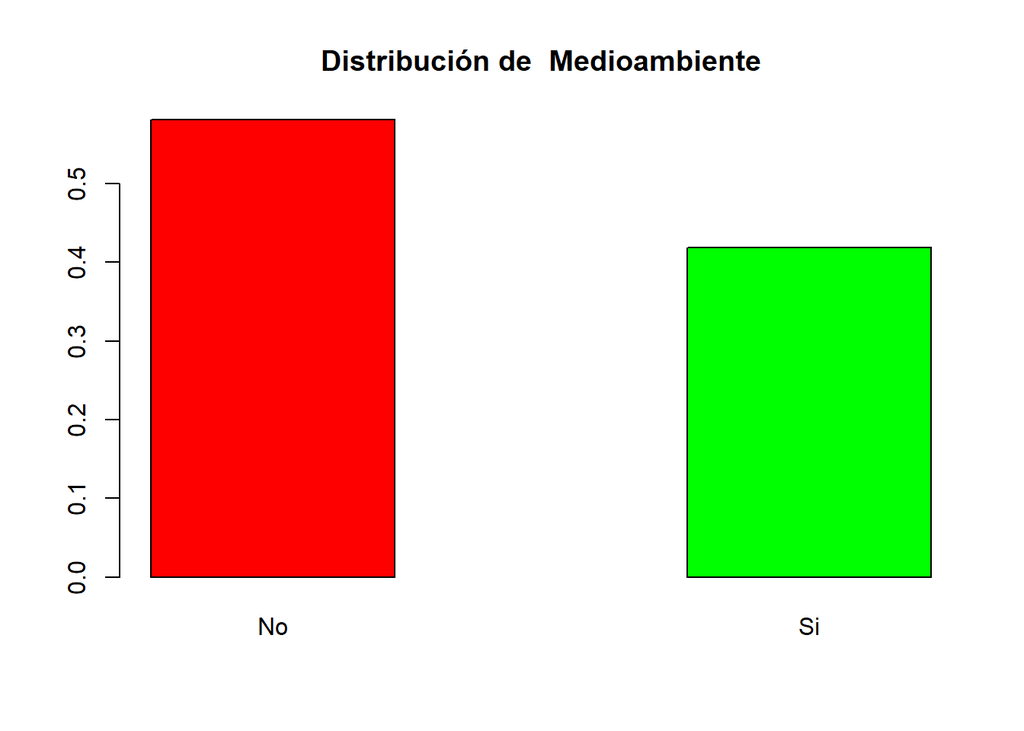

```
## [1] "Grupo_Apoyo"
```

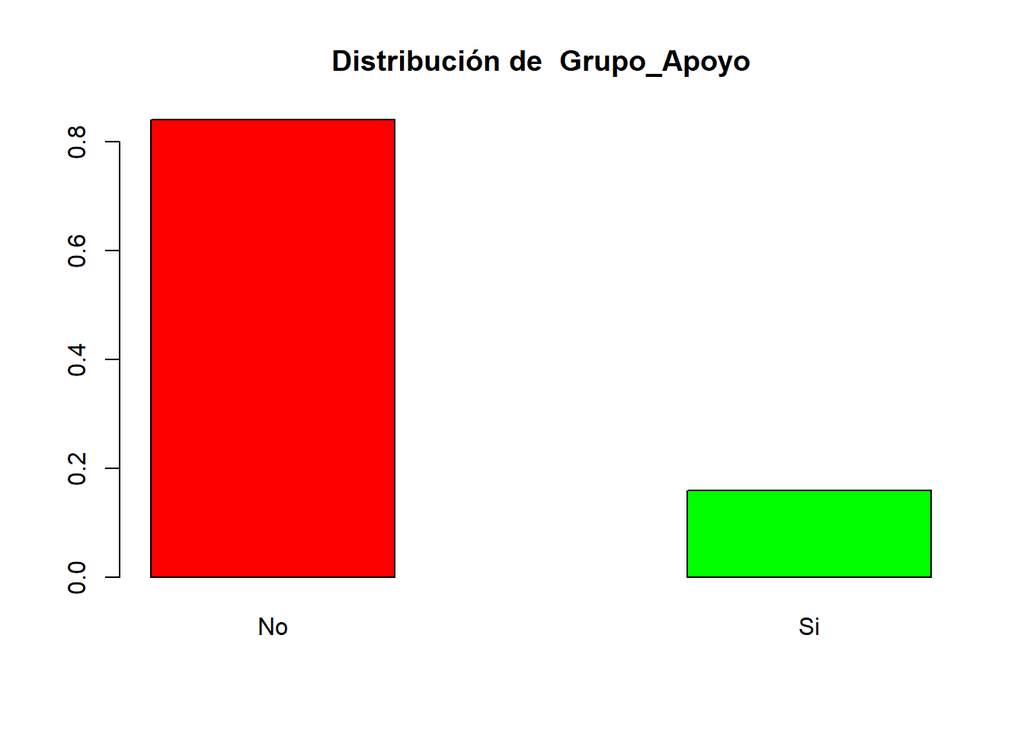

```r
dataset_factors =dataset[,sapply(dataset, is.factor)]

for (f_name in colnames(dataset[,sapply(dataset, is.factor)])){
  print(f_name)
  barplot(prop.table(table(dataset[,f_name])),main = paste("Distribución de ",f_name),
          space = 1.2, axisnames = TRUE, col = rainbow(3))
}
```

## Selección de los datos

Para seleccionar los datos a utilizar, vamos a revisar la distribución de los valores en las diferentes columnas utilizando el comando summary:

```r
summary(dataset)
```

```
##  Tiempo_Respuesta Tiempo_comunidad Sexo     Trabaja        Edad       Familia
##  Min.   : 2.010   Corto: 714       F:1790   No:1739   Min.   :17.00   No:2125
##  1st Qu.: 3.875   Largo:1465       M:1693   Si:1744   1st Qu.:27.00   Si:1358
##  Median : 5.930   Medio:1304                          Median :36.00
##  Mean   : 5.922                                       Mean   :36.73
##  3rd Qu.: 7.840                                       3rd Qu.:46.00
##  Max.   :10.150                                       Max.   :57.00
##  Hobbies   Club_Social Politica  Profesional Medioambiente Grupo_Apoyo
##  No:2438   No:2828     No:3156   No:2353     No:2025       No:2930
##  Si:1045   Si: 655     Si: 327   Si:1130     Si:1458       Si: 553
##
##
##
##
##     Trabaja1
##  Min.   :0.0000
##  1st Qu.:0.0000
##  Median :1.0000
##  Mean   :0.5007
##  3rd Qu.:1.0000
##  Max.   :1.0000
```

Revisando los datos, podemos observar que en dos variables *Club_Social* y *Politica* existe un desbalance importante en la distribución de los valores, con mas del 80% de las observaciones con un solo valor:

[output not shown]

Debido a esto, no seran consideramos para el análisis.

```r
dataset$Club_Social <- NULL
dataset$Politica <- NULL
dataset$Trabaja1 <- NULL
```

## Limpieza de los datos

Para asegurar el correcto funcionamiento del algoritmo, vamos a aplicar la función na.omit a fin de remover cualquier valor nulo, existe.

```r
dataset<- na.omit(dataset)
```

## Construcción de nuevos datos (atributos)

Se crearon dos nuevas variables como el rango de edad y el tiempo de respuesta para agrupar los datos. Para ambas variables se crearon 3 subgrupos. Una vez creados estas nuevas variables se procede a eliminar las variables originales.

```r
dataset$Grupo_Edad<-discretize(dataset$Edad,method="frequency",breaks = 3, labels = c("Edad_Joven","Edad_Media","Edad_Mayor"))
levels(dataset$Grupo_Edad)
```

```
## [1] "Edad_Joven" "Edad_Media" "Edad_Mayor"
```

```r
dataset$Grupo_Tiempo_Respuesta<-discretize(dataset$Tiempo_Respuesta,method="frequency",breaks = 3,
                                           labels = c("Tiempo_Respuesta_Rapida","Tiempo_Respuesta_Media","Tiempo_Respuesta_Lenta"))
levels(dataset$Grupo_Tiempo_Respuesta)
```

```
## [1] "Tiempo_Respuesta_Rapida" "Tiempo_Respuesta_Media"
## [3] "Tiempo_Respuesta_Lenta"
```

```r
dataset$Edad <- NULL
dataset$Tiempo_Respuesta <- NULL

str(dataset)
```

```
## 'data.frame':    3483 obs. of  10 variables:
##  $ Tiempo_comunidad      : Factor w/ 3 levels "Corto","Largo",..: 1 3 3 2 2 2 3 3 1 3 ...
##  $ Sexo                  : Factor w/ 2 levels "F","M": 2 1 2 1 2 1 1 2 1 2 ...
##  $ Trabaja               : Factor w/ 2 levels "No","Si": 1 1 1 1 2 1 2 2 1 1 ...
##  $ Familia               : Factor w/ 2 levels "No","Si": 2 1 2 1 1 1 1 2 2 1 ...
##  $ Hobbies               : Factor w/ 2 levels "No","Si": 1 1 2 1 1 1 1 2 2 1 ...
##  $ Profesional           : Factor w/ 2 levels "No","Si": 1 1 2 1 2 2 1 1 2 1 ...
##  $ Medioambiente         : Factor w/ 2 levels "No","Si": 1 2 1 1 1 1 1 2 2 2 ...
##  $ Grupo_Apoyo           : Factor w/ 2 levels "No","Si": 1 2 1 1 2 1 2 1 1 2 ...
##  $ Grupo_Edad            : Factor w/ 3 levels "Edad_Joven","Edad_Media",..: 3 2 2 2 1 2 2 1 3 1 ...
##   ..- attr(*, "discretized:breaks")= num  17 30 43 57
##   ..- attr(*, "discretized:method")= chr "frequency"
##  $ Grupo_Tiempo_Respuesta: Factor w/ 3 levels "Tiempo_Respuesta_Rapida",..: 3 2 1 2 1 3 1 1 2 1 ...
##   ..- attr(*, "discretized:breaks")= num  2.01 4.56 7.24 10.15
##   ..- attr(*, "discretized:method")= chr "frequency"
```

```r
colnames(dataset)
```

```
##  [1] "Tiempo_comunidad"       "Sexo"                   "Trabaja"
##  [4] "Familia"                "Hobbies"                "Profesional"
##  [7] "Medioambiente"          "Grupo_Apoyo"            "Grupo_Edad"
## [10] "Grupo_Tiempo_Respuesta"
```

En el caso de edad estos grupos son: Edad_Joven (De 17 a 30 años), Edad_Media (30 a 43 años) y Edad_Mayor (43 a 57 años)

En el caso de Tiempo_Respuesta los 3 subcojuntos son: Tiempo_Respuesta_Rapida de 2.01 a 4.56 minutos,Tiempo_Respuesta_Media de 4.56 a 7.24 minutos y Tiempo_Respuesta_Lenta de 7.24 a 10.15 minutos.

## Transformaciones aplicadas a los datos

En este caso todo el desarrollo de la tarea se realiza a través de R. El detalle de las modificaciones se encuentra en los apartados Preparación de los datos: Selección de los datos, Limpieza de los datos y Construcción de nuevos datos.

# Fase de modelado

## Selección de técnicas (en este caso A priori)

Para esta tarea se hace uso de la técnica A priori, tomando en consideración el conocimiento aprendido en clase y las instrucciones brindadas por la profesora para la creación de esta tarea.

## Construcción del modelo (en este caso serán conjuntos de reglas)

### Modelo 1

#### Selección de los parámetros

Para la creación del primer conjunto de reglas se hace uso de todas originales (excepto Politica y Club Social) a fin de explorar los resultados de las reglas generadas.

```r
#transacciones <- col_concat(dataset,sep=",")
transacciones<-as(dataset,Class = "transactions")
head(transacciones)
```

```
## transactions in sparse format with
##  6 transactions (rows) and
##  23 items (columns)
```

```r
 # se guardan los datos como archivo csv en formato transaccion
write(transacciones,'transaccionesv1.csv',sep=',')
#write.csv(transacciones,'transaccionesv1.csv',quote = FALSE)
```

##### Exploración de las transacciones

Para explorar las transacciones creadas, se utiliza el comando summary, en el mismo es posible ver que los items más frecuentes son: Grupo_Apoyo=No, Profesional=No, Medioambiente=No, Hobbies=No y Familia=No

```r
summary(transacciones)
```

```
## transactions as itemMatrix in sparse format with
##  3483 rows (elements/itemsets/transactions) and
##  23 columns (items) and a density of 0.4347826
##
## most frequent items:
##   Grupo_Apoyo=No       Hobbies=No   Profesional=No       Familia=No
##             2930             2438             2353             2125
## Medioambiente=No          (Other)
##             2025            22959
##
## element (itemset/transaction) length distribution:
## sizes
##   10
## 3483
##
##    Min. 1st Qu.  Median    Mean 3rd Qu.    Max.
##      10      10      10      10      10      10
##
## includes extended item information - examples:
##                   labels        variables levels
## 1 Tiempo_comunidad=Corto Tiempo_comunidad  Corto
## 2 Tiempo_comunidad=Largo Tiempo_comunidad  Largo
## 3 Tiempo_comunidad=Medio Tiempo_comunidad  Medio
##
## includes extended transaction information - examples:
##   transactionID
## 1             1
## 2             2
## 3             3
```

#### Ejecución (generación de reglas, eliminación de subconjuntos,etc)

##### Generación de las reglas usando A priori

Vamos a utilizar un soporte del 0.1 (10%) para filtrar los items que tienen una baja frecuencia, es decir que tienen una baja frecuencia de aparición en la misma transacción. Igualmente utilizamos una confianza de 0.9 (90%) para incluir items con una alta probabilidad de ocurrencia.

```r
 # se generar las reglas usando el algoritmo a priori, con un soporte del 1% y una confianza de 0.9 o 90%
  reglas<- apriori(transacciones,parameter = list(supp=0.1,conf=0.9,maxlen=10))
```

```
## Apriori
##
## Parameter specification:
##  confidence minval smax arem  aval originalSupport maxtime support minlen
##         0.9    0.1    1 none FALSE            TRUE       5     0.1      1
##  maxlen target   ext
##      10  rules FALSE
##
## Algorithmic control:
##  filter tree heap memopt load sort verbose
##     0.1 TRUE TRUE  FALSE TRUE    2    TRUE
##
## Absolute minimum support count: 348
##
## set item appearances ...[0 item(s)] done [0.00s].
## set transactions ...[23 item(s), 3483 transaction(s)] done [0.00s].
## sorting and recoding items ... [23 item(s)] done [0.00s].
## creating transaction tree ... done [0.00s].
## checking subsets of size 1 2 3 4 5 6 done [0.00s].
## writing ... [69 rule(s)] done [0.00s].
## creating S4 object  ... done [0.00s].
```

```r
  inspect(reglas[1:10])
```

```
##      lhs                                                 rhs            support confidence     lift count
## [1]  {Medioambiente=No,
##       Grupo_Edad=Edad_Joven}                          => {Hobbies=No} 0.1673844  0.9024768 1.289305   583
## [2]  {Medioambiente=No,
##       Grupo_Tiempo_Respuesta=Tiempo_Respuesta_Rapida} => {Hobbies=No} 0.1757106  0.9066667 1.295291   612
## [3]  {Medioambiente=No,
##       Grupo_Tiempo_Respuesta=Tiempo_Respuesta_Lenta}  => {Hobbies=No} 0.1762848  0.9029412 1.289969   614
## [4]  {Medioambiente=No,
##       Grupo_Edad=Edad_Media}                          => {Hobbies=No} 0.1788688  0.9002890 1.286180   623
## [5]  {Familia=No,
##       Medioambiente=No}                               => {Hobbies=No} 0.3870227  0.9302968 1.329050  1348
## [6]  {Medioambiente=No,
##       Grupo_Apoyo=No}                                 => {Hobbies=No} 0.4424347  0.9001168 1.285934  1541
## [7]  {Familia=No,
##       Medioambiente=No,
##       Grupo_Edad=Edad_Joven}                          => {Hobbies=No} 0.1263279  0.9341826 1.334601   440
## [8]  {Profesional=No,
##       Medioambiente=No,
##       Grupo_Edad=Edad_Joven}                          => {Hobbies=No} 0.1119724  0.9027778 1.289735   390
## [9]  {Medioambiente=No,
##       Grupo_Apoyo=No,
##       Grupo_Edad=Edad_Joven}                          => {Hobbies=No} 0.1421189  0.9032847 1.290460   495
## [10] {Familia=No,
##       Profesional=Si,
##       Medioambiente=No}                               => {Hobbies=No} 0.1297732  0.9319588 1.331424   452
```

```r
  # eliminar reglas que son subconjuntos de otras
  subconjuntos<- which(colSums(is.subset(reglas,reglas))>1)

  reglasFinal<- reglas[-subconjuntos]
  #inspect(reglasFinal[1:10])

  # se ordena por soporte y se observan las primeras 10 reglas
  inspect(sort(reglasFinal,by='lift',decreasing = TRUE)[1:10])
```

```
##      lhs                                                 rhs                support confidence     lift count
## [1]  {Familia=No,
##       Medioambiente=No}                               => {Hobbies=No}     0.3870227  0.9302968 1.329050  1348
## [2]  {Tiempo_comunidad=Largo,
##       Sexo=F,
##       Medioambiente=No}                               => {Hobbies=No}     0.1208728  0.9132321 1.304671   421
## [3]  {Medioambiente=No,
##       Grupo_Tiempo_Respuesta=Tiempo_Respuesta_Rapida} => {Hobbies=No}     0.1757106  0.9066667 1.295291   612
## [4]  {Sexo=F,
##       Trabaja=Si,
##       Medioambiente=No}                               => {Hobbies=No}     0.1403962  0.9055556 1.293704   489
## [5]  {Medioambiente=No,
##       Grupo_Tiempo_Respuesta=Tiempo_Respuesta_Lenta}  => {Hobbies=No}     0.1762848  0.9029412 1.289969   614
## [6]  {Medioambiente=No,
##       Grupo_Edad=Edad_Joven}                          => {Hobbies=No}     0.1673844  0.9024768 1.289305   583
## [7]  {Trabaja=Si,
##       Profesional=No,
##       Medioambiente=No}                               => {Hobbies=No}     0.1780075  0.9011628 1.287428   620
## [8]  {Medioambiente=No,
##       Grupo_Edad=Edad_Media}                          => {Hobbies=No}     0.1788688  0.9002890 1.286180   623
## [9]  {Medioambiente=No,
##       Grupo_Apoyo=No}                                 => {Hobbies=No}     0.4424347  0.9001168 1.285934  1541
## [10] {Sexo=M,
##       Trabaja=Si,
##       Hobbies=No,
##       Profesional=No}                                 => {Grupo_Apoyo=No} 0.1004881  0.9020619 1.072314   350
```

```r
  # se filtran las reglas con confianza superior a 0.25
  mejoresReglas<- reglasFinal[quality(reglasFinal)$confidence>0.90]
```

```r
# se leerá el archivo como transacciones formato basket
 transacciones<- read.transactions('transaccionesv1.csv',sep=',',format = 'basket')
```

#### Descripción general de las reglas obtenidas (incluya al menos un gráfico)

##### Visualización de las 3 mejores reglas (según confianza) - grafo

La visualización a través del grafo, nos permite apreciar como las variables MedioAmbiente=No y Hobbies=No se relacionan con las 3 reglas más fuertes, en la sección “Evaluación de los modelos” brindará más detalle de las interpretaciones de cada regla.

```r
   tresMejoresReglas<- head(mejoresReglas,n=3,by='lift')
   plot(tresMejoresReglas,method = 'graph',engine = 'htmlwidget')
```

[interactive chart not shown]

##### Visualización de 3 reglas - gráfico paracoord

El siguiente gráfico nos permite apreciar que hay una relación fuerte entre los items Hobbies=No y MedioAmbiente=No

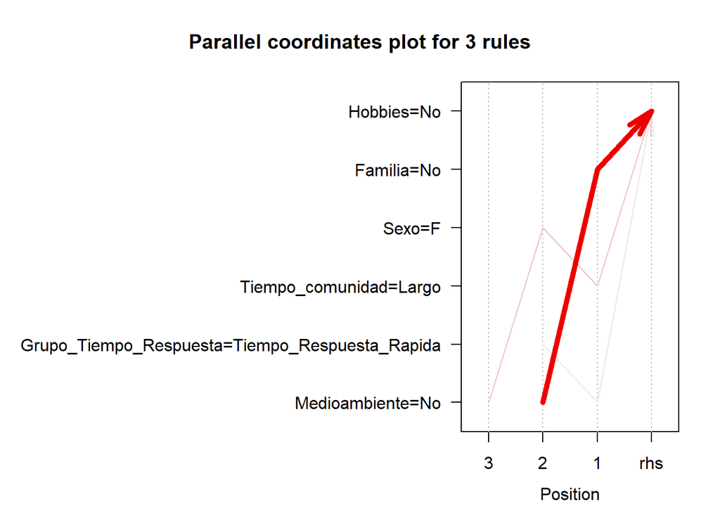

```r
# graficar 10 reglas individuales para observar lhs y rhs
  Top3<-head(mejoresReglas,n=3,by='confidence')
  plot(Top3,method ='paracoord')
```

#### Evaluación de los modelos

##### Muestre e interprete las mejores 3 reglas de cada conjunto generado

Las mejores reglas al utilizar todas las siguientes:

```r
inspect(Top3)
```

```
##     lhs                                                 rhs            support confidence     lift count
## [1] {Familia=No,
##      Medioambiente=No}                               => {Hobbies=No} 0.3870227  0.9302968 1.329050  1348
## [2] {Tiempo_comunidad=Largo,
##      Sexo=F,
##      Medioambiente=No}                               => {Hobbies=No} 0.1208728  0.9132321 1.304671   421
## [3] {Medioambiente=No,
##      Grupo_Tiempo_Respuesta=Tiempo_Respuesta_Rapida} => {Hobbies=No} 0.1757106  0.9066667 1.295291   612
```

Como se puede apreciar en la tabla anterior las 3 mejores reglas del modelo nos permiten identificar que caracteristicas pueden ayudarnos a identificar si una persona no tiene hobbies.

- Regla 1: En el caso de la regla 1 hay un 93% de probabilidad de que si la persona no tiene familia y no pertenece a un grupo de apoyo al medio ambiente, implica que la persona no tiene hobbies.
- Regla 2:En el caso de la regla 2 hay un 91.33% de probabilidad de que si la persona ha vivido durante un periodo largo, es mujer y no pertenece a un grupo de apoyo al medio ambiente, implica que la persona no tiene hobbies.
- Regla 3:Y la regla 3 indica que hay un 90.66% de probabilidad de que si la persona no pertenece a un grupo de apoyo al medio ambiente y contestó rápido la encuesta, implica que la persona no tiene hobbies.

### Modelo 2

##### Generación de las reglas usando A priori

Para el segundo modelo se utiliza un soporte más bajo de 0.02(2%), la confianza en 0.7 (70%) y el maxlen en 5, esto con el propósito de flexibilizar las restricciones del modelo, pero al mismo tiempo reducir el número de items empleadas por el algoritmo al generar las reglas, y asi comparar los resultados de ambos modelos

```r
 # se generarn las reglas usando el algoritmo a priori, con un soporte del 2% y una confianza de 0.7%

  reglasv2<- apriori(transacciones,parameter = list(supp=0.02,conf=0.7,maxlen=5))
```

```
## Apriori
##
## Parameter specification:
##  confidence minval smax arem  aval originalSupport maxtime support minlen
##         0.7    0.1    1 none FALSE            TRUE       5    0.02      1
##  maxlen target   ext
##       5  rules FALSE
##
## Algorithmic control:
##  filter tree heap memopt load sort verbose
##     0.1 TRUE TRUE  FALSE TRUE    2    TRUE
##
## Absolute minimum support count: 69
##
## set item appearances ...[0 item(s)] done [0.00s].
## set transactions ...[23 item(s), 3483 transaction(s)] done [0.00s].
## sorting and recoding items ... [23 item(s)] done [0.00s].
## creating transaction tree ... done [0.00s].
## checking subsets of size 1 2 3 4 5
```

```
##  done [0.01s].
## writing ... [8065 rule(s)] done [0.00s].
## creating S4 object  ... done [0.01s].
```

```r
  inspect(reglasv2[1:10])
```

```
##      lhs                                                 rhs                  support confidence      lift count
## [1]  {}                                               => {Grupo_Apoyo=No}   0.8412288  0.8412288 1.0000000  2930
## [2]  {Tiempo_comunidad=Corto}                         => {Grupo_Apoyo=No}   0.1731266  0.8445378 1.0039335   603
## [3]  {Hobbies=Si}                                     => {Medioambiente=Si} 0.2388745  0.7961722 1.9019670   832
## [4]  {Hobbies=Si}                                     => {Grupo_Apoyo=No}   0.2400230  0.8000000 0.9509898   836
## [5]  {Grupo_Edad=Edad_Joven}                          => {Grupo_Apoyo=No}   0.2644272  0.8342391 0.9916911   921
## [6]  {Profesional=Si}                                 => {Hobbies=No}       0.2282515  0.7035398 1.0050981   795
## [7]  {Profesional=Si}                                 => {Grupo_Apoyo=No}   0.2583979  0.7964602 0.9467818   900
## [8]  {Grupo_Tiempo_Respuesta=Tiempo_Respuesta_Rapida} => {Hobbies=No}       0.2360034  0.7098446 1.0141053   822
## [9]  {Grupo_Tiempo_Respuesta=Tiempo_Respuesta_Rapida} => {Grupo_Apoyo=No}   0.2805053  0.8436960 1.0029329   977
## [10] {Grupo_Tiempo_Respuesta=Tiempo_Respuesta_Lenta}  => {Hobbies=No}       0.2385874  0.7151463 1.0216795   831
```

```r
  # eliminar reglas que son subconjuntos de otras
  subconjuntosv2<- which(colSums(is.subset(reglasv2,reglasv2))>1)

  reglasFinalv2 <- reglasv2[-subconjuntosv2]

  # se ordena por soporte y se observan las primeras 3 reglas
  inspect(sort(reglasFinalv2,by='lift',decreasing = TRUE)[1:3])
```

```
##     lhs                                                 rhs                   support confidence     lift count
## [1] {Hobbies=Si}                                     => {Medioambiente=Si} 0.23887453  0.7961722 1.901967   832
## [2] {Grupo_Tiempo_Respuesta=Tiempo_Respuesta_Rapida,
##      Hobbies=Si,
##      Profesional=No,
##      Sexo=F}                                         => {Familia=Si}       0.02325581  0.7043478 1.806512    81
## [3] {Familia=No,
##      Grupo_Edad=Edad_Mayor,
##      Grupo_Tiempo_Respuesta=Tiempo_Respuesta_Rapida,
##      Tiempo_comunidad=Largo}                         => {Trabaja=Si}       0.02124605  0.7254902 1.448900    74
```

```r
  # se filtran las reglas con confianza superior a 0.25
  mejoresReglasv2<- reglasFinalv2[quality(reglasFinalv2)$confidence>0.70]
```

```r
# se leerá el archivo como transacciones formato basket
 transaccionesv2 <- read.transactions('transaccionesv1.csv',sep=',',format = 'basket')
```

#### Descripción general de las reglas obtenidas (incluya al menos un gráfico)

##### Visualización de las 3 mejores reglas (según confianza) - grafo

Mediante el gráfico 2 es posible observar que al flexibilizar los parámetros del modelo, se incluyen en las reglas items que no tienen un soporte tan alto en comparación con el modelo 1.

```r
   tresMejoresReglasv2 <- head(mejoresReglasv2,n=3,by='lift')
   plot(tresMejoresReglasv2,method = 'graph',engine = 'htmlwidget')
```

[interactive chart not shown]

El siguiente gráfico nos permite apreciar que hay una relación fuerte entre los items Hobbies=Si y MedioAmbiente=Si

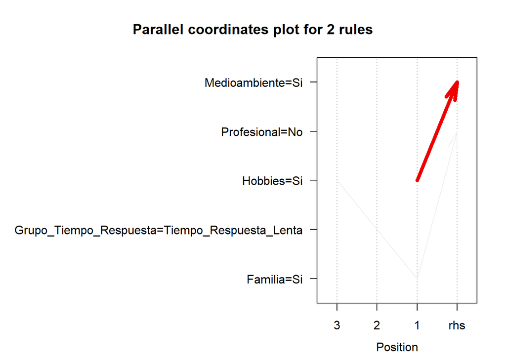

```r
# graficar 10 reglas individuales para observar lhs y rhs
  Top3v2<-head(mejoresReglasv2,n=3,by='confidence')
  plot(Top3v2,method ='paracoord')
```

#### Evaluación de los modelos

##### Muestre e interprete las mejores 3 reglas de cada conjunto generado

Las mejores reglas al utilizar todas las siguientes:

```r
inspect(Top3v2)
```

```
##     lhs                                                rhs                   support confidence     lift count
## [1] {}                                              => {Grupo_Apoyo=No}   0.84122883  0.8412288 1.000000  2930
## [2] {Hobbies=Si}                                    => {Medioambiente=Si} 0.23887453  0.7961722 1.901967   832
## [3] {Familia=Si,
##      Grupo_Tiempo_Respuesta=Tiempo_Respuesta_Lenta,
##      Hobbies=Si}                                    => {Profesional=No}   0.04105656  0.7371134 1.091103   143
```

- Regla 1: En el caso de la regla 1 del segundo modelo, en principio esta regla indican que sin importar la característica (individual) en LHS, en el RHS vendrá GrupoApoyo=No.
- Regla 2: La regla 2 nos indica que hay un 79%.62 de confianza que si la persona tiene Hobbies, entonces la probabilidad de que también pertenezca a un grupo de medio ambiente es de 1.9 veces.
- Regla 3: La regla 3 nos indica que si la persona tiene familia, contestó la encuesta en un periodo de tiempo lento, y tiene hobbies implica que hay un 73.71% probabilidad de que no sea profesional.

# Conclusiones de la comparación de los modelos

Al comparar los modelos es posible notar que al flexibilizar los parámetros (soporte, confianza, maxlen o cantidad de variables consideradas por el modelo), más items son considerados en el modelo 2, que pueden ser de utilidad para la creación de los grupos y cumplir con el objetivo de negocio, esto considerando que los items del modelo 1 tienen un conjunto de variables limitado, y quizás se requiere más flexibilidad a la hora de agrupar a los diferentes miembros de la comunidad. En el primer grupo estamos restringuiendo los parametros de forma que surgen 2 items con una asociación muy fuerte (Hobbies=No y MedioAmbiente=No), sin embargo esto no puede ser de utilidad para los objetivos del negocio por lo que el segundo modelo al flexibilizar los parámetros, incluye items que pueden permitir un agrupamiento más realista de las personas de la comunidad.